# Caffeine Costs: A Data Analysis of My Caffeine Spending Habits

Author

Tushna Elavia

Caffeine is one of the commonly accepted and normalised substances in modern society. As someone who struggles with Polycystic Ovary Syndrome (PCOS), I have often been advised to quit caffeine. In addition to health reasons, these drinks are also my biggest daily expense. By viewing my caffeine spending habits through a visual, data-driven lens, I hope to become more intentional about my caffeine intake and purchases. Through my data story, I aim to understand where I spend my money, on which types of drinks, the cumulative cost of purchasing drinks and whether there are any changes or trends on when I decide to purchase drinks during the course of the semester.

I collected and recorded data every time I ordered a drink. I usually order it once a day, but if it’s twice, I record the price both times. I created an Excel sheet with the following categories: Date, Coffee Shop, Exact Order, Drink Type (Coffee, Matcha or Chai), Cost (in $) and Notes. I updated the Excel sheet every week on Mondays and used my Notes and Bank of America App to track the order and cost daily. During the first half of the semester, I lost my Bank of America card and tracked the receipts on my Thomas Cook card. Additionally, I accounted for every time I attended an Open Tab event by listing the total price as 0 US dollars for those specific drinks.

While creating the graphs, I made them as accessible as possible by using colourblind friendly colours and adding alt text.

[interactive chart not shown]

The horizontal bar chart above shows the amount of money I spent in Peter Bs and the Underground Coffeehouse (UG). I spent a total of $291.8 on my drinks from February 1st to April 16th, 2026. Out of which, I spent $153.3 at the UG and $138.5 at PeterBs. To create this chart, I first filtered the data by coffee shop and calculated the total amount of money spent at each location. I then created a pivot table to find the cost of drinks I spent on PeterBs vs the Underground Coffeehouse.

I was surprised to observe that I spent more money at the UG than I did at PeterBs. This is because I get a student mentor discount at the UG, making the cost of each drink slighly cheaper than PeterBs. In retrospect, this bar chart makes sense as I frequent the Underground Coffeehouse more often than PeterBs. This is probably because my friend is the manager the Underground Coffeehouse and I often study there during her shifts.

Overall, having a visual representation of where I am spending my money helps me better understand my spending habits and where I want to make changes. I was expecting the total costs to be much higher. I suspect this is because my data does not account for the money I spent on caffeinated drinks off campus during this period.

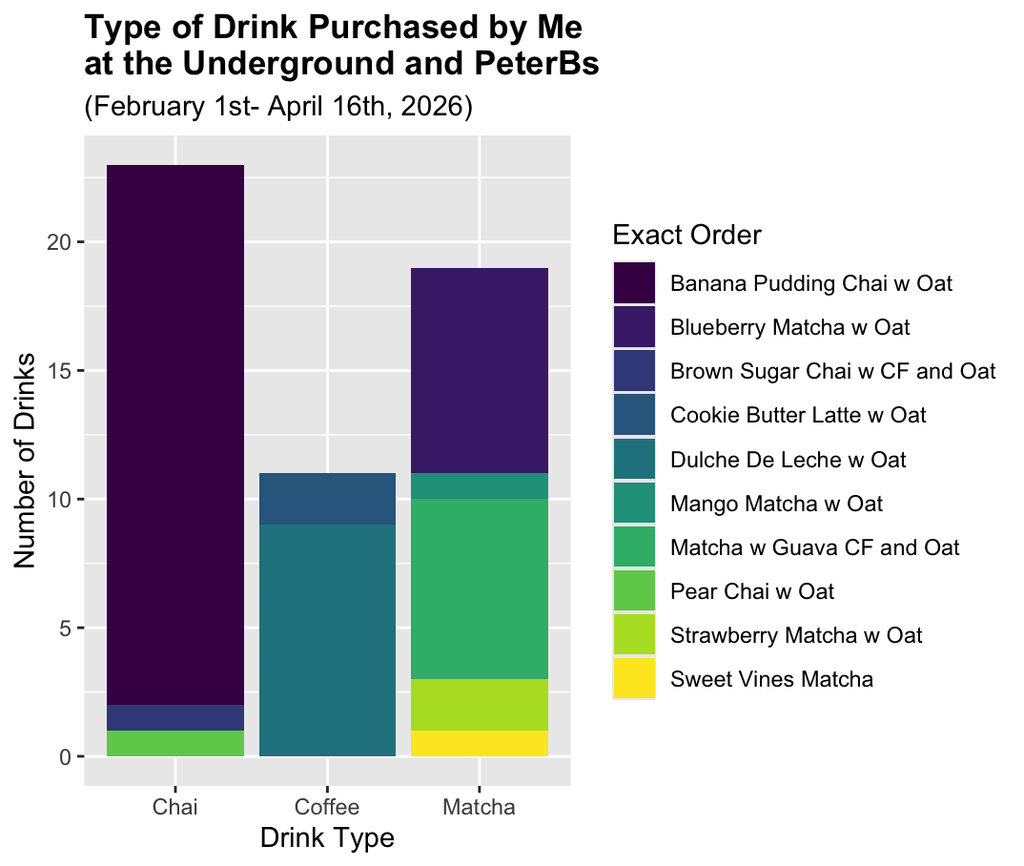

The stacked bar graph above illustrates the number of times I ordered a chai, coffee, or matcha. The X axis shows the type of drink (chai, coffee or matcha) I purchased and the Y axis is the number of drinks. Within each bar, I colour coded the exact drink order to add nuance. As observed in the graph, I ordered chai 23 times, coffee 11 times and matcha 19 times from February 1st to April 16th. I used ggplot2 in R Studio to make this graph and imported my Excel sheet.

My most common chai and overall order was a Banana Pudding Chai with oat milk. Similarly, I mainly ordered a Dulce De Leche with oat milk when it came to my coffee order and Blueberry Matcha with oat milk was my most common matcha order. I also ordered a Sweet Vines Matcha and a Mango Matcha once, making those my most unique drink orders. Through this graph, I learned that once I find a drink I like, I tend to stick to it and reorder. It also gave me a data-driven insight into my favourite drinks as my friends always ask me for my on campus drink suggestions.

The first version of the bar chart was a simple bar chart that showed the number of times I purchased a chai, matcha, or coffee. I then decided to add the exact order type within those larger categories to add nuance to my graph. I also considered creating a table instead that shows the exact count of drinks purchased. However, I chose a stacked bar graph instead as I wanted to provide my audience with a visual understanding of approximately how many times I chose one drink type over another, rather than exact numbers.

[interactive chart not shown]

Lastly, this is a cumulative area graph that shows the cumulative money spent on drinks at the Underground Coffeehouse and PeterBs from February 1st to April 16th, 2026. The X axis shows the date and the Y axis shows the cumulative cost of the drinks purchased by me in US dollars. By April 16th, 2026 I spent a total of $291.8 on caffeinated drinks.

To create this graph, I manually input all dates in the time period, including those on which I did not purchase a drink. I initially created an area graph but changed it to a cumulative one as it still shows the general trend of when I bought drinks while also showing cumulative spending at the end of the semester.

As observed in the cumulative area graph, the longest periods I went without purchasing are from February 10th to February 15th, 2026 and from March 17th to March 22nd, 2026. Upon reflecting, I observed that the first plateau in February was when I first lost my Bank of America card and had decided to not use my Thomas Cook card yet due to the conversion cost from pounds to US dollars. The second plateau in March is because I was on Spring Break and bought coffee at off-campus locations instead.

All in all, these graphs provided me with a concrete understanding of where I spend my money (the UG or PeterBs), my exact drink orders and change in my spending habits during the course of the semester.

While $291.8 over the span of 11 weeks might not look like a lot, this averages to $26.53 per week which is a substantial portion of my current weekly income as a student who only works part time. The projected cost is around $1,379 per year which again could be invested, saved or spent on larger, intentional purchases including travel. At the same time, trying out different specialty drinks and working with my friends definitely increases my productivity and gives me something to look forward to on a day-to-day basis. I also tend to rely on caffeine during academically tense and stressful periods. Post graduation, I intend to prepare my drinks at home to save money and find alternative social activities to meet up with my friends that do not always involve purchasing a drink.